# HW2

Sukhman Parhar

2026-03-11

## load and clean the data

```r
# Load in the data
college <- read_csv("College.csv")
# look at the data
#str(college)
#dim(college)
#summary(college)
#colSums(is.na(college))

# clean the data

# remove college var
college <- college %>% select(-College)

# cap grad rate at 100% anything above is impossible
college$Grad.Rate[college$Grad.Rate > 100] <- 100

college <- na.omit(college)
```

## Data partition

```r
set.seed(2)

data_split <- initial_split(college, prop = 0.8)

training_data <- training(data_split)
testing_data  <- testing(data_split)
```

## Question 1: Smoothing Spline Models

```r
set.seed(2)
pred.grid <- seq(from = -10, to = 110, by = 1)

# predictor and response
x <- training_data$Top10perc
y <- training_data$Outstate

# smoothing splines with different df
fit3  <- smooth.spline(x, y, df = 3)
fit5  <- smooth.spline(x, y, df = 5)
fit7  <- smooth.spline(x, y, df = 7)
fit10 <- smooth.spline(x, y, df = 10)
```

### Plot

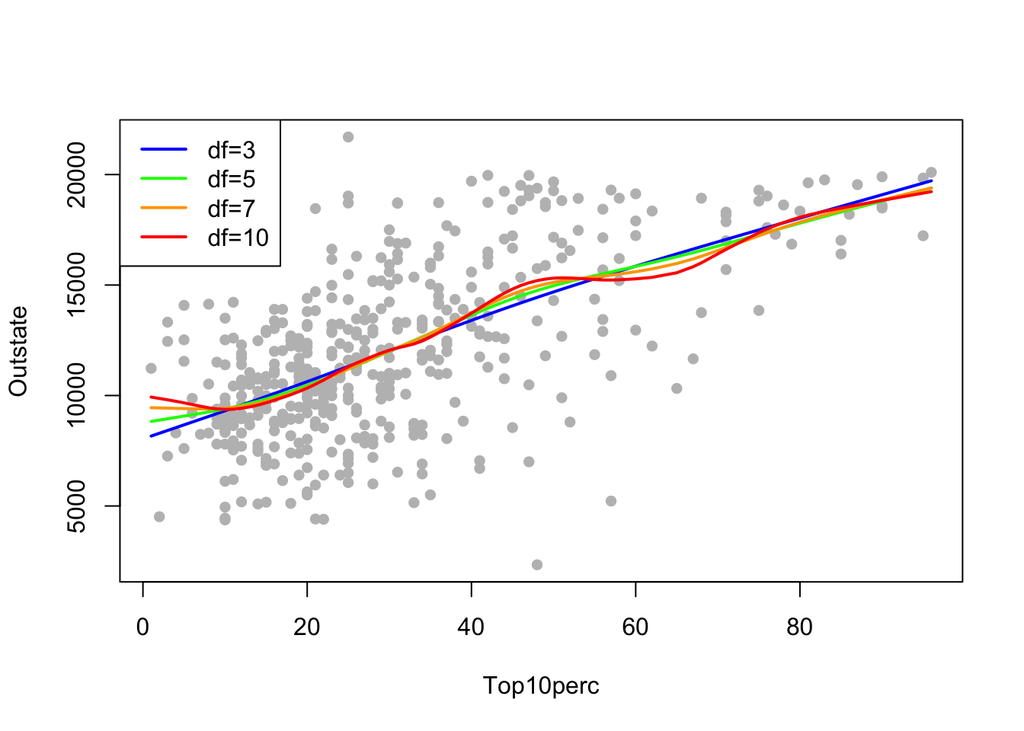

```r
plot(x, y,
     col = "grey",
     pch = 16,
     xlab = "Top10perc",
     ylab = "Outstate")

lines(predict(fit3), col = "blue", lwd = 2)
lines(predict(fit5), col = "green", lwd = 2)
lines(predict(fit7), col = "orange", lwd = 2)
lines(predict(fit10), col = "red", lwd = 2)

legend("topleft",
       legend = c("df=3","df=5","df=7","df=10"),
       col = c("blue","green","orange","red"),
       lwd = 2)
```

### Find optimal fit

```r
set.seed(2)

fit.opt <- smooth.spline(training_data$Top10perc,
                         training_data$Outstate)

fit.opt$df
```

```
## [1] 4.514771
```

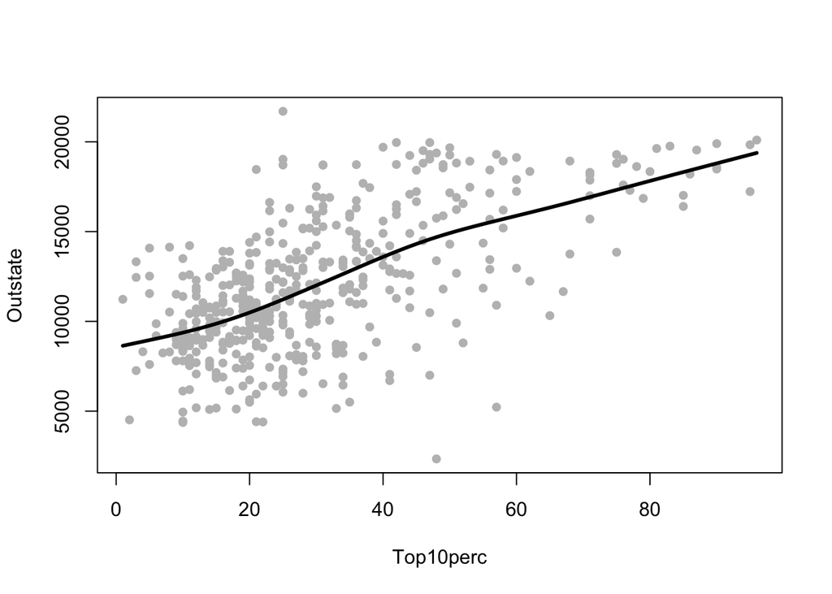

```r
plot(training_data$Top10perc,
     training_data$Outstate,
     col = "grey",
     pch = 16,
     xlab = "Top10perc",
     ylab = "Outstate")

lines(fit.opt, col = "black", lwd = 3)
```

When we increase the df the smoothing spline becomes more flexible and follows the data more. Meaning that the lines we see for lower df are smoother and higher df curve more.

The optimal degree of freedom was selected using generalized cross-validation through the smooth.spline() function. The appropriate df was 4.514771 which means there is a smooth relationship between Top10perc and Outstate tuition.

## Question 2: MARS

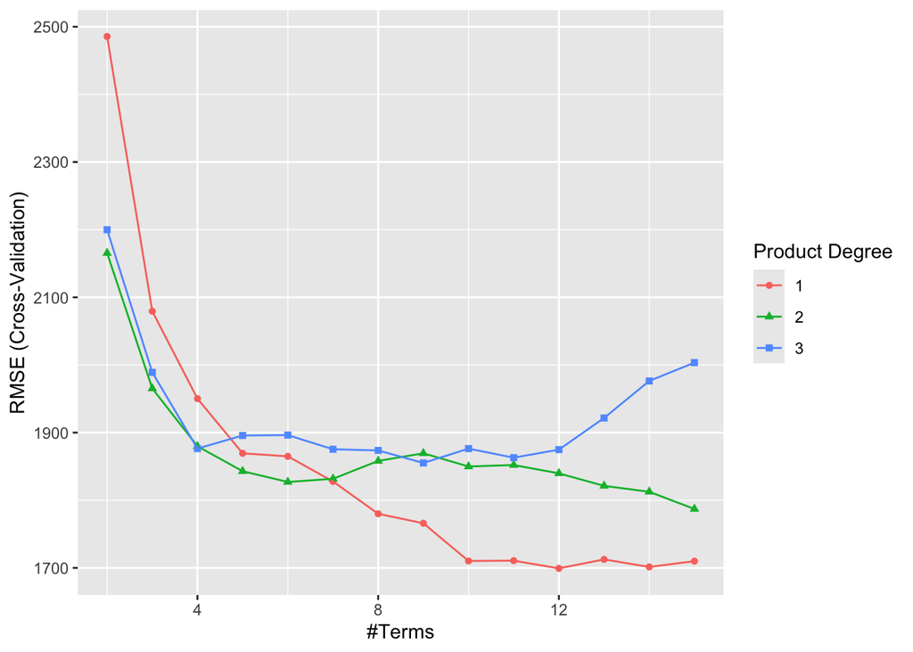

```r
# matrix of predictors
x <- model.matrix(Outstate ~ ., training_data)[, -1]

# vector of response
y <- training_data$Outstate

# ten-fold CV
ctrl1 <- trainControl(method = "cv", number = 10)

# tuning grid
mars_grid <- expand.grid(degree = 1:3,
                         nprune = 2:15)

set.seed(2)
mars.fit <- train(
  x, y,
  method = "earth",
  trControl = ctrl1,
  tuneGrid = mars_grid
)

ggplot(mars.fit)
```

```r
mars.fit$bestTune
```

```
##    nprune degree
## 11     12      1
```

```r
coef(mars.fit$finalModel)
```

```
##         (Intercept)     h(Expend-15387)     h(83-Grad.Rate)  h(5895-Room.Board)
##        9769.7409173          -0.7713811         -28.1496701          -0.6958227
## h(1363-F.Undergrad)    h(1230-Personal)        h(Apps-3646)       h(Enroll-913)
##          -1.9394339           0.8523499           0.4626452          -1.9835630
##       h(913-Enroll)      h(2279-Accept)    h(perc.alumni-6)      h(Expend-6898)
##           6.3726039          -1.9009022          25.5286028           0.7515357
```

### Regression Function

$$\hat{Outstate} =
9769.741
-0.771\,h(Expend-15387)
-28.150\,h(83-Grad.Rate)
-0.695\,h(5895-Room.Board)
-1.939\,h(1363-F.Undergrad)
+0.852\,h(1230-Personal)
+0.462\,h(Apps-3646)
-1.984\,h(Enroll-913)
+6.373\,h(913-Enroll)
-1.901\,h(2279-Accept)
+25.529\,h(perc.alumni-6)
+0.752\,h(Expend-6898)$$
### PDP

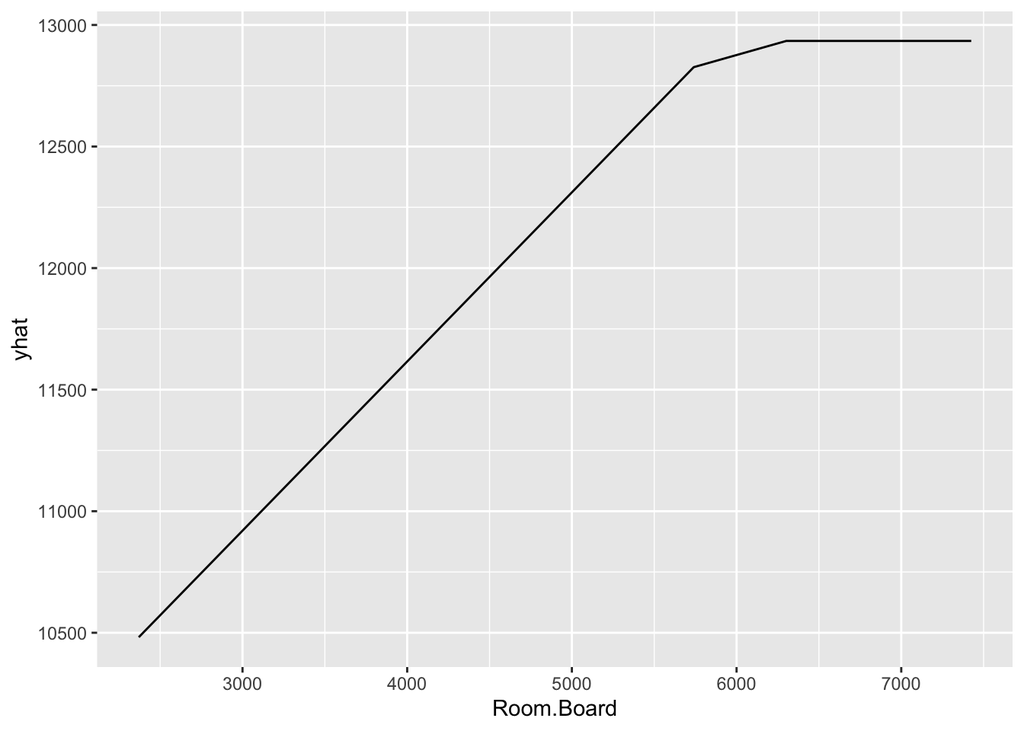

```r
p1 <- pdp::partial(mars.fit, pred.var = "Room.Board", grid.resolution = 10) |> autoplot()

p1
```

### Test MSE

```r
mars_preds <- predict(mars.fit, newdata = testing_data )
test_mse <- mean((testing_data $Outstate - mars_preds)^2)
print(paste("MARS Test MSE:", round(test_mse, 2)))
```

```
## [1] "MARS Test MSE: 3436224.71"
```

The model selected 12 our of 22 terms and used 9 of the 16 predictors.

MSE = 3,436,224.71

## Question 3: GAM

```r
set.seed(2)

gam.mod <- gam(
  Outstate ~ s(Apps) + s(Accept) + s(Enroll) + s(Top10perc) + s(Top25perc) +
    s(F.Undergrad) + s(P.Undergrad) + s(Room.Board) + s(Books) +
    s(Personal) + s(PhD) + s(Terminal) + s(S.F.Ratio) +
    s(perc.alumni) + s(Expend) + s(Grad.Rate),
  data = training_data
)

# Summary of model
gam_sum <- summary(gam.mod)

# Find smooth terms with edf > 1
nonlinear_idx <- which(gam_sum$s.table[, "edf"] > 1.001)

# See which terms these are
rownames(gam_sum$s.table)[nonlinear_idx]
```

```
##  [1] "s(Apps)"        "s(Accept)"      "s(Top10perc)"   "s(F.Undergrad)"
##  [5] "s(Room.Board)"  "s(PhD)"         "s(S.F.Ratio)"   "s(perc.alumni)"
##  [9] "s(Expend)"      "s(Grad.Rate)"
```

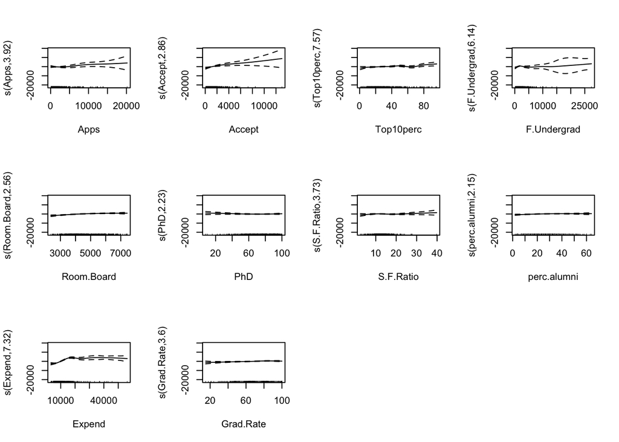

```r
# Set plotting layout
par(mfrow = c(3, 4))

# Plot only nonlinear smooth terms
for (i in nonlinear_idx) {
  plot(gam.mod,
       select = i,
       shade = TRUE,
       seWithMean = TRUE)
}
```

The Generalized Additive Model plots indicate several nonlinear relationships between predictors and out-of-state tuition. Instructional expenditure per student shows the strongest effect, with tuition increasing sharply as expenditure rises before leveling off at higher values. Room and board costs and the percentage of alumni who donate both display positive relationships with tuition, suggesting that institutions with higher housing costs and stronger alumni support tend to charge higher tuition. The number of full-time undergraduates and the number of accepted students show mild nonlinear patterns, indicating that tuition changes differently across smaller and larger institutions. Graduation rate also exhibits a slight positive nonlinear trend, suggesting that schools with higher graduation rates tend to have somewhat higher tuition.

### Test MSE

```r
set.seed(2)

#y predicted values from testing data
gam.pred = predict(gam.mod, newdata = testing_data)

#actual y values from testing data
y2 = testing_data$Outstate

mean((y2 - gam.pred)^2)
```

```
## [1] 3441623
```

MSE = 3441623

## Question 4: In this dataset, would you favor a MARS model over a linear model for predicting out-of-state tuition?

### Compare RMSEs of MARS model with linear model

```r
set.seed(2)
lm.fit <- train(
  Outstate ~ .,
  data = training_data,
  method = "lm",
  trControl = ctrl1
)

# compare cross-validated results
resamp <- resamples(list(
  mars = mars.fit,
  lm   = lm.fit
))

summary(resamp)
```

```
##
## Call:
## summary.resamples(object = resamp)
##
## Models: mars, lm
## Number of resamples: 10
##
## MAE
##          Min.  1st Qu.  Median     Mean  3rd Qu.     Max. NA's
## mars 1140.699 1238.456 1339.28 1336.997 1420.260 1611.957    0
## lm   1429.028 1575.835 1612.05 1608.093 1675.061 1748.244    0
##
## RMSE
##          Min.  1st Qu.   Median     Mean  3rd Qu.     Max. NA's
## mars 1377.340 1548.425 1712.799 1699.292 1846.042 2121.059    0
## lm   1772.592 1954.852 2027.582 2047.675 2114.624 2390.484    0
##
## Rsquared
##           Min.   1st Qu.    Median      Mean   3rd Qu.      Max. NA's
## mars 0.7296508 0.7659017 0.8056078 0.8021930 0.8427998 0.8680554    0
## lm   0.6579702 0.7141846 0.7235299 0.7206688 0.7442131 0.7685136    0
```

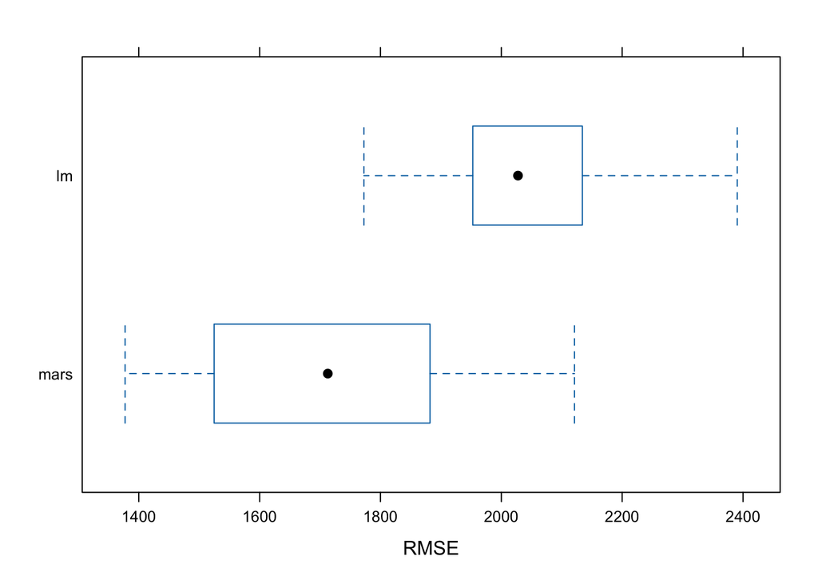

```r
# boxplot of RMSE
bwplot(resamp, metric = "RMSE")
```

```r
# test MSE for linear model
lm.pred <- predict(lm.fit, newdata = testing_data)
lm_mse <- mean((testing_data$Outstate - lm.pred)^2)
print(paste("Linear Model Test MSE:", round(lm_mse, 2)))
```

```
## [1] "Linear Model Test MSE: 3184829.67"
```

The mean RMSE for the Multivariate Adaptive Regression Splines model is **1699.292** and the mean RMSE for the linear model is **2047.675**. The median RMSE for the Multivariate Adaptive Regression Splines model is **1712.799** and the median RMSE for the linear model is **2027.582**. Based on the mean RMSEs for each model, the Multivariate Adaptive Regression Splines model has a smaller RMSE and its cross-validation performance is better than the linear model. I would favor the Multivariate Adaptive Regression Splines model over the linear model for predicting out-of-state tuition. However, when examining the test Mean Squared Errors, the test Mean Squared Error for the linear model (**3184829.67**) is smaller than the test Mean Squared Error for the Multivariate Adaptive Regression Splines model (**3436224.71**). This is the opposite of my above decision but we rely on cross-validation when test data are unavailable. That is why MARS is a better choice.

## Question 5: In practical applications, would you consider a MARS model to be superior to a linear model, or the other way around?

In practical applications, I would not say that a MARS model is always superior to a linear model. A MARS model is more flexible because it builds a piecewise linear model using hinge basis functions and can capture nonlinear predictor-response relationships automatically, which is helpful when the data show curvature or threshold effects. However, a linear model is preferable when the relationships are linear, when interpretability is important, or when a simpler model gives similar accuracy. I would choose MARS when there is evidence of meaningful nonlinearity and improved prediction, but I would favor a linear model when simplicity, interpretability, and comparable performance are more important.